# Econometria de Séries de Tempo

Leonardo C. Geri Universidade Federal do ABC

Anotações para a discipina de Econometria III.

# Considerações Iniciais

## 1ª diferença

$$\Delta = y_t - y_{t-1}$$

## 2ª diferença

$$\Delta² = \Delta(\Delta y_t)=$$
$$\Delta y_t - \Delta y_{t-1}=$$
$$y_t - y_{t-1} - y_{t-1} - y_{t-2} =$$
$$y_t - 2 y_{t-1} + y_{t-2}$$

## Defasagem

$$y_{t-1} = L y_t$$
$$L² y_t = L(L y_t) = L(y_{t-1}) = y_{t-2}$$

Aplicando a defasagem à 2ª diferença:

$$\Delta y_t = y_t - y_{t-1}$$
$$\Delta y_t = y_t -L y_t$$
$$\Delta y_t = y_t - L y_t$$
$$\Delta y_t = (1-L) y_t$$
$$\Delta y_t = 1-L$$
$$\Delta² = (1-L)²$$
Aplicando produto notável $= 1 -2L + L²$ $\Delta⁴ = 1-4L+6L² -4L³+l⁴$

# Especificação do Processo Estocástico

## Definição de Komogorov

Se conhecermos as distribuições finitas dimensionais $F(x_1, x_2, ..., x_n; t_1, t_2, ..., t_n) = Pr [x(t_1), x(t_2), ... , x(t_n) \leq x_n]$, com $t_1 \in T, i=1,2,...,n$ e se elas satisfazem as condições de **simetria** e **compatibilidade**, então o processo estocástico $x(t,\omega), t \in T, \omega \in \Omega$ estará plenamente especificado.

### i) Simetria

Essa condição nos diz que, se permutarmos a ordem das distribuições de $x$, que são função do tempo, a nossa probabilidade final não muda $(F)$.

Matematicamente, temos:

$$F(x_{j1}, x_{j2}, ..., x_{jn}; t_{j1}, t_{j2}, ..., t_{jn} =$$
$$F(x_{1}, x_{2}, ..., x_{n}; t_{1}, t_{2}, ..., t_{n}$$

### ii) Compatibilidade

Para um numero grande de observações (tendendo ao infinito), as informações não acrescentam nada para entender a estrutura de probabilidade do processo estocástico. Em outras palavras, a certo ponto, diante de um determinado número de observações, jã sabemos tudo que precisamos saber sobre a distribuição. Dessa forma, podemos dispensar novas observações se as que já tivermos até então forem suficientes.

Matematicamente, temos para $m<n$:

$$\lim_{m+1\rightarrow \infty} F(x_{1}, x_{2}, ..., x_{n}; t_{1}, t_{2}, ..., t_{n}$$
$$F(x_{1}, x_{2}, ..., x_{n}; t_{1}, t_{2}, ..., t_{n}$$

## Aplicação às Ciências Econômicas

Dentro das Ciências Econômicas, estamos diante da impossibilidade de se obter uma distribuição estatística para cada realização. Por exemplo, possuímos uma realização para o PIB de 1980, mas não um conjunto de realizações que nos forneçam a distribuição de probabilidades para o mesmo ano, o que é possível para as Ciências Exatas, por meio do laboratório. Essa dificuldade faz com que a Economia não possa se apropriar desse caso de Processo Estocástico.

Formalmente, em termos práticos, a utilização do conceito de Processo Estocástico baseado em uma especificação “estrita” é muito difícil de ser aplicado às Ciências Econômicas, pois raramente conhecemos as distribuições para processo estocástico. Alternativamente, podemos estudar as estatísticas associadas à distribuição conjunta que sejam simples de calculas e interpretar: *Primeiro e Segundo Momentos Estatísticos*.

### Primeiro Momento: função média ou função esperança

$$\mu(t) = E[x(t)] = \int_{\infty}^{\infty} fxdx$$

### Segundo Momento: função autocovariância

Nota: A covariância mede o grau de dependência linear entre duas variáveis.

$$\gamma(t_1, t_2 = Cov[x(t_1,t_2)])$$
$$E[x(t_1).x(t_2)] - E[x(t_1)] . E[x(t_2)] . E[x(t_2)]$$

#### Caso específico

Para o caso específico em que falamos sobre o mesmo instante de tempo $t$, ou seja, $t_1=t_2=t$, podemos substituir os valores de $t$ na fórmula acima de $\gamma$

$$\gamma(t, t) = Cov[x(t), x(t)]$$
$$E[x(t).x(t)] - E[x(t)] . E[x(t)] . E[x(t)]$$
$$E[x(t)]² - E[x(t)]² = Var[x(t)]$$

Ou seja, o $\gamma$ se torna a variância de $t$.

Assim, a classe de processo estocástico não é útil para a Economia. Precisamos utilizar a classe particular dos **processos estocásticos estacionários**.

## Processos Estocásticos Particulares

### Processo Ruído Branco

Ocorre quando as ditrsibuições são independentes (covariância, ou seja, dependência linear, é igual a zero).

Se estamos no mesmo periíodo de tempo, a variância é igual a zero:

$$E(y_t) = 0$$
e
$$cov(y_t, y_{t+h} = \begin{cases} \sigma²_y, & \mbox{se} h/{=0} \\ 0, & \mbox{se} h/{\neq 0}) \end{cases}$$

### Processo Ruído Branco Gaussiano

$$x_t ~N(\mu, \sigma_x²)$$

Se todas as médias forem iguais, a função é constante com uma distribuição com média $\mu$ e variância $\sigma²$

Def.: Dizemos que $x_t$ é um processo ruído branco gaussiano se cada elemento de $x_t$ tiver distribuição normal com média $\mu$ e variância $\sigma^2$.

### Processo i.i.d.

# Estacionariedade

As medidas que serão vistas nesse curso são modelos paramétricos cujos *coeficientes não variam no tempo*. Dessa forma, são requeridas certas condições de “estabilidade” de determinadas propriedades estatísticas dos dados (processos estocásticos) em relação ao tempo:

**Genericamente**: $Prop.Est.(x_t) = Prop.Est(x_t+h), t, h \in \mathbb{Z}$

## Estaticionariedade Forte

Def: Dizemos que o processo estocástico $x_t$ é fortemente ou estritamente estacionário se todas as distribuições finito-dimensionais que definem o processo permanecem inalteradas sob translações no tempo:

$$F(x_1, x_2, ..., x_n; t_{1+h},t_{2+h}, ..., t_{n+h})= F(x_1, x_2, ..., x_n; t_1, t_2, ..., t_n)$$
**Restrição para aplicação:** Em termos práticos, a utilização do conceito de estacionariedade forte é difícil de ser implementada, dado que não conhecemos todas as distribuições do processo estocástico (nas séries econômicas, vemos apenas uma observação por instante no tempo, e não uma distribuição de probabilidade completa), além do fato dela ser bastante restritiva.

Precisamos, então, de uma condição de estabilidade estatística apropriada ao grupo de modelos de processos estocásticos que iremos enfocar no curso (estacionariedade fraca).

## Estacionariedade Fraca

Def: Dizemos que um processo estocástico $x_t$ é fracamente estacionário, ou ainda estacionário de Estacionário de Segunda Ordem ou Covariância Estacionário, se e somente se ele satisfizer três condições:

1. de que a média do processo estocástico seja constante $E(x_t) = \mu(const)$
2. de que a variância do processo estocástico não seja explosiva (divergente) $Var(x_t) < +\infty$
3. a covariância do processo em relação ao t é uma função gamma que depende apenas da distância h (depende da distância lag h ou defasagem, e não de t) $Cov(x_t, x_{t \pm h}) = \gamma(|h|), para h \in \mathbb{Z}$

Estabelece condições apenas relativas ao dois momentos estatísticos, e não diz nada a respeito das distribuições. Por isso, esse tipo de estacionariedade é muito menos restritiva.

Seja $x_t$ um processo estocástico fracamente estacionário com média zero, isto é, $E(x_t)=0$, e Função de Autocovariância (FAC) $\gamma(t, t \pm h) = \gamma (|h|) = E(x_t.x_{t \pm h})$. Neste caso:

1. Covariância no tempo zero (variância) é positiva:

$$\gamma(0)>0$$

2. A função é simétrica (em formato de V). Por isso, podemos analisar apenas os casos positivos:

$$\gamma(-h)= \gamma(+h)$$

3. O módulo do $\gamma_h$ vai ser semrpe menor ou igual a sua variância:

$$|\gamma_h| \leq \gamma(0)$$

4. $\gamma(h)$ é não negativa definida:

$$\sum_j \sum_k a_j a_k \gamma (h_j, h_k) \geq 0; \forall a_j a_k \in \mathbb{R}$$

Adicionalmente, se $x_t$ é estacionário, os valores convergem rapidamente para zero:

$$\lim_{|h|\rightarrow +\infty} \gamma (|h|) = 0$$

*Como base nessas propriedades, podemos buscar indícios sobre a estacionariedade de uma série temporal empírica analisando sua FACV ou FAC. Caso os valores calculados de FACV e FAC “entrem” rapidamente para dentro (me permitam o pleonasmo como um exercício de fixação) do intervalo de confiança, haverá indício de que ela covnerge rapidamente para zero (verificar gráfico de FAC no apêndice computacional).*

### Exercício

Verificar para os casos específicos (ruído branco, ruído branco gaussiano, i.i.d. e *random walk* se são fracamente ou fortemente estacionários.

Os três primeiros são fracamente estacionários, para *random walk* não se pode garantir nenhuma propriedade.

# Filtros e Processos Lineares

Def: Seja ${x_t}_{t \ in \mathbb{Z}}$ uma série estacionária de entrada ou *input* e seja ${y_t}_{t \ in \mathbb{Z}}$ uma série de saída ou *output*. Um filtro linear aplica os coeficientes ${\psi_j}_{j \in \mathbb{Z}}$ sobre a série $x_t$ e gera a série $y_t$:

$$x_t \longrightarrow \psi_\beta \longrightarrow y_t$$
Matematicamente, a “filtragem” é feita por meio da **convolução**:

$$y_t = \sum_{j = -\infty}^{+\infty} \psi_j x_{t-j}$$
Os coeficientes ${\psi_j}_{j \in \mathbb{Z}}$ são chamados de Função Impulso-Resposta e satisfazer a condição de serem absolutamente somáveis:

$$\sum_{j = -\infty}^{+\infty} |\psi_j| < +\infty$$
## Processo Linear

# Processos AR(p)

Para introduzir um processo autoreregressivo, tomemos como exemplo um processo AR(1), onde lê-se *processo estocástico autoregressivo de primeira ordem*, representado pela equação:

$$Y_t = \alpha_1Y_{t-1} + \mu_t$$
Nesse caso, temos o valor de $Y_t$ dependendo do seu valor anterior e de um termo aleatório. Em outras palavras, o modelo informa que o valor previsto de $Y$ no período $t$ é uma proporção $\alpha$ somado a um choque aleatório no período $t$. A perturbação em processos AR é do tipo *ruído branco*, isto é, possui média zero e variância constante $\sigma²$.

Esse processo pode ser expandido de forma a obtermos diferentes ordens para AR(p), e não somente AR(1). Um exemplo de processo AR(2), ou seja, em que a variável $Y$ no período $t$ depende de seu valor nos dois períodos anteriores, é:

$$Y_t = \beta_1Y_{t-1} + \beta_2Y_{t-2} + \mu_t$$

## Condição de estacionariedade em processos AR

De forma bastante resumida, a condição de estacionariedade para o processo AR(1) indicado na seção anterior é descrita por:
$$|\phi_1| < 1$$

Já no caso dos processos AR(2), deve-se atender à seguintes condições:

$$\phi_1 + \phi_2 < 1$$
$$\phi_1 - \phi_2 < 1$$
$$-1 < \phi_2 < 1$$

## Média em processos AR

Considerando que o modelo descrito atenda à condição descrita acima, tem-se que a média em um processo AR(1) é

$$E(Y_t) = \frac{\alpha_1}{(1-\alpha_1)} = \mu$$
Provando-se, portanto, que a esperança condicional de $Y_t$ é constante e invariante no tempo.

Em um processo AR(2), a média é:
$$E(X_t) = \frac{\alpha_1}{(1-\alpha_1 - \alpha_2)} = \mu$$

## Variância em processos AR(1)

A variância de um processo AR(1), quando $|\alpha_1| <1$ é constante e igual a:

$$\sigma²_x = E[(Y_t - \mu² )] = \frac{\sigma²_e}{1-\sigma²}$$

# Processos MA(q)

Um processo é dito de Médias Móveis quando uma variável explicada em um período específico do tempo é igual a uma contante mais uma *média móvel* dos termos do erro atuais e passados. Diferentemente do processo AR, não assumimos que em MA o processo é ruído branco. Vemos uma equação para um processo MA(1):

$$Y_t = \mu + \beta_0 \mu_t + \beta_1 \mu_{t-1}$$
De forma análoga, um processo MA(2) segue a equação:

$$Y_t = \mu + \beta_0 \mu_t + \beta_1 \mu_{t-1} + \beta_2 \mu_{t-2}$$

Finalmente, de forma generalizada, um processo MA(q) é escrito como:

$$Y_t = \mu + \beta_0 \mu_t + \beta_1 \mu_{t-1} + \beta_2 \mu_{t-2} + ... + \beta_q \mu_{t-q}$$

## Média e variância em MA

Assim como nos processos AR, a média é constante e invariante no tempo.

A média pode ser facilmente demonstrada, chegando-se a:

$$E[Y_t] = E[\theta_0 + \epsilon+ \theta_1 \epsilon_{t-1}]$$
, como sabemos que a esperança dos termos do erro é sempre constante,
$$E[Y_t] = E[\theta_0$$
também sabemos que a esperança de uma constante é igual à própria constante, então
$$E[Y_t] = \theta_0$$

# Ordem de Integração e Raízes Unitárias

Em uma série temporal, a integração diz respeito à estacionariedade. De forma geral, dizemos que se uma série é integrada de ordem 1, estamos dizendo que a série se torna estacionária na sua primeira diferença. Sobre essa mesma série, podemos dizer que ela possui **raíz unitária**.

Isto é, processos com ordem de integração iguais ou superiores a 1 são não-estacionários, e, geralmente, precisamos aplicar o operador *diff* para que os resultados obtidos em uma regressão não sejam **espúrios**. Por outro lado, se trabalhamos com uma série $I(0)$, dizemos que a série é estacionária.

Generalizando, para tornar uma série $I(d)$ estacionária, diferenciamos $d$ vezes para obter uma série $I(0)$.

# Funções de Autocorrelação (ACF)

A função de Autocorrelação é um instrumento gráfico para a identificação de estacionariedade em uma série (ver apêndice computacional). Dessa forma, um gráfico com a autocorrelação decaindo muito lentamente é um indicativo de uma série com autocorrelação. Podemos dizer que no gráfico do apêncide computacional, o processo registrado é ruído branco, devido à a ausência de autocorrelação, enquanto um processo passeio aleatório apresentaria um comportamento bastante diferente.

## A identificação de modelos ARMA(p, q) por meio da FAC e FACP

É possível verificar, de forma gráfica, qual a ordem dos processos AR e MA utilizando as funções de Autocorrelação e Autocorrelação Parcial, embora a precisão desse método seja considerada baixa.

Para fazê-lo, precisamos, em primeiro lugar, ter em mente que a *FAC* está associado ao processo de médias móveis *MA*; por outro lado, o processo FACP está associado ao processo autoregressivo *AR*:

| Função | Processo |
| --- | --- |
| FAC | MA(q) |
| FACP | AR(p) |

## Alguns padrões teoréticos encontrados na FAC E FACP

Por fim, a tabela a seguir indica alguns padrões encontrados nas funções, de acordo com o tipo de modelo observado (GUJARATI):

| Modelo | Padrão na FAC | Padrão na FACP |
| --- | --- | --- |
| AR(p) | Declina exponencialmente ou com padrão de onde senóide | Picos significativos até $p$ defasagens |
| MA(q) | Picos significativos até $q$ defasagens | Declina exponencialmente |
| ARMA(p,q) | Queda exponencial | Queda exponencial |

# Identificação da Ordem de Integração: Os testes de raíz unitária

Um ponto central na literatura sobre séries temporais é a estacionariedade. Dessa forma, é muito relevante identificar a ordem de integração $I(d)$ antes de começar a trabalhar com determinadas séries. Para isso, estão disponíveis alguns métodos econométricos.

Essencialmente, possuímos três testes bastante aplicados, sendo eles: Dickey-Fuller aumentado, Phillips-Perron e KPSS.

Esses testes são chamados de testes de raíz unitária, porque, a princípio, testam se a ordem de uma série é $I(0)$ ou $I(1)$. Isso é equivalente a testar se uma série é estacionária ou não.

Os testes de Dickey-Fuller aumentado e Phillips-Perron compartilham as mesmas hipóteses, sendo elas:

$$\begin{cases} H_0, I(1) \\ H_1, I(0) \end{cases}$$

O que é equivalente a testar se:

$$\begin{cases} H_0, não-estacionário \\ H_1, estacionário \end{cases}$$

Os testes são unicaudais para o lado esquerdo (negativo), dessa forma, se o valor associado à série for *menor* do que o valor crítico, aceitamos a hipótese alternativa. De forma análoga, se o valor for *maior*, não é possível rejeitar a hipótese nula.

Por que, então, apresentamos dois testes para as mesmas hipóteses? Isso ocorre porque o teste de Phillips-Perron usa métodos não-paramétricos para tratas da correlação serial nos termos do erro sem adicionar os termos de diferença defasados.

Alternativamente, o teste KPSS inverte as hipóteses:

$$\begin{cases} H_0, estacionário \\ H_1, não-estacionário \end{cases}$$

# Quando não confiar em um modelo? O caso das regressões espúrias

Uma regressão é dita espúria quando se obtem estatísticas que indicam significância (como um $R²$ não muito baixo e coeficientes significantes), porém não é possível encontrar uma interpretação econômica para essa série. Essa é uma das principais razóes pelas quais os testes de raíz unitária devem ser realizados no estudo de séries temporais. Se estamos trabalhando com duas séries $I(0)$, ou seja, estacionárias, podemos utilizar o método dos Mínimos Quadrados Ordinários.

Assumindo-se duas séries $y_t$ e $Z_t$, regredidas uma com outra, podemos obter resultados espúrios nos casos em que:

- $y_t$ e $Z_t$ são integrados de diferentes ordens
- $y_t$ e $Z_t$ são integrados de mesma ordem, porém o resíduo é diferente de $I(0)$

Podemos usar uma regressão convencional no caso em que

- $y_t$ e $Z_t$ são ambos estacionários, ou seja, $I(0)$

No caso específico em que duas séries integradas de mesma ordem possuem como resíduo uma série estacionário, dizemos que existe **cointegração** entre as séries.

# Cointegração

A cointegração representa uma **relação de equilíbrio no longo prazo**. Ela ocorre quando possuímos duas séries com raíz unitária $I(1)$, porém, ao regredí-las, obtemos um resíduo estacionário I(0).

Isso significa que essas séries, individualmente, não são estacionárias, porém, no longo prazo, “flutuam” juntas, de forma a criar resíduos estacionários.

O conceito de cointegração tem relevância pois, quando aplicamos um modelo ARIMA em diferença, perdemos informações de longo prazo ao diferenciá-la.

## Teste de cointegração Engle-Granger

O teste de Engle-Granger segue as hipóteses:

$$\begin{cases} H_0, não-cointegração \\ H_1, cointegração \end{cases}$$
Para isso, primeiro é necessário verificar se as séries que se deseja testar (chamamos aqui de $X_t$ e $Y_T$) são estacionárias. Para isso, podemos aplicar um teste de Raíz Unitária simples (ADF, PP ou KPSS).

Tendo verificado que $X$ e $Y$ são não estacionários, prosseguimos para a verificação de estacionariedade nos resíduos, onde devemos verificar a estacionariedade.

Uma precaução relevante, no entanto, é que os valores de $\mu_t$ estimado é baseado no parâmetro de cointegração *estimado* $\beta_2$, tornando os valores críticos de um teste ADF não muito apropriados. Uma pequena adaptação é necessária nos valores críticos, que foram calculados por Engle-Granger.

# Modelos ARCH - Autoregressive Conditional Heterokedascity

## 1ª equação para média condicionada

$$y_t = X\beta + \mu_t$$
$$\mu_t = \sigma_tz_t$$
(equação para o termo do erro) onde $\sigma^2 = w + a\mu ^ 2_{t-1} + \beta \sigma^2_{t-1}$ que varia no tempo e é um ruído branco, que demonstra o componente heterocedástico (uma memória dependendo do termo do erro e uma memória dependente da variância)

Esse modelo é chamado de GARCH(1,1) já que possui um termo do erro defasado e um termo $^ 2 $ também defasado.

# Apêndice computacional

### Gerando um processo ruído branco gaussiano

#### Gerando uma normal

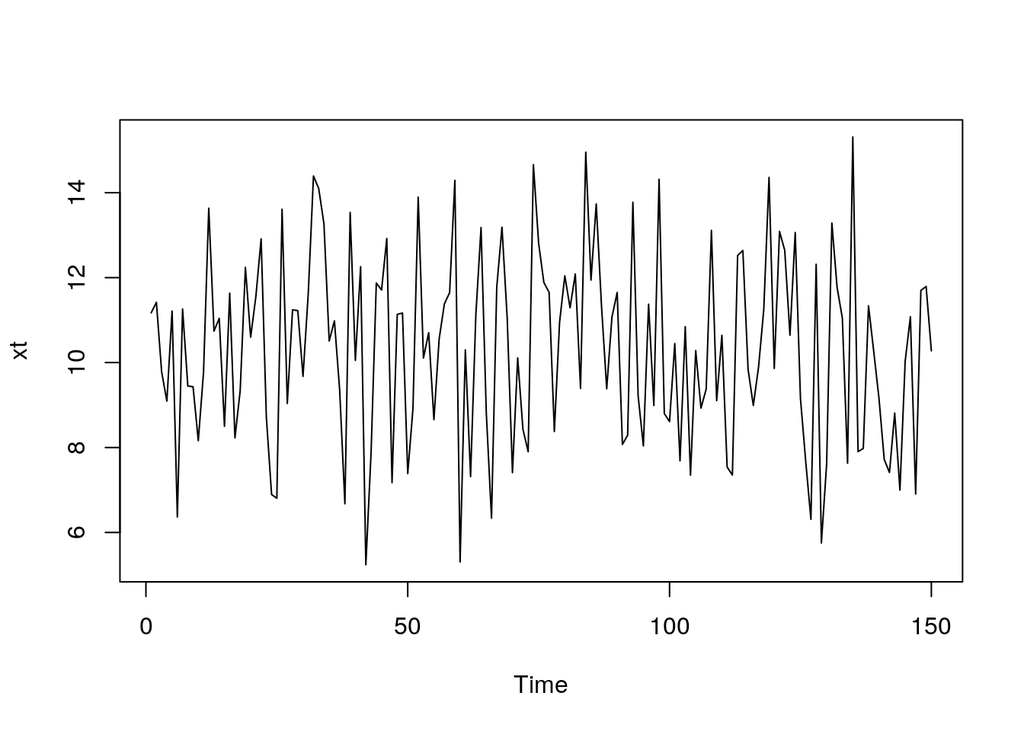

```r
set.seed(12345)
xt <- rnorm(150, 10, 2)
plot.ts(xt)
```

#### Média

```r
mean(xt)
```

```
## [1] 10.31826
```

Notar que a média não é exatamente igual a 10. Isso ocorre porque estamos trabalhando com dados de simulação e valores amostrais. No entanto, o valor da média converge para 10. Caso aumentemos o tamanho da amostra, a média se aproxima do valor esperado 10:

```r
set.seed(12345)
xt_2 <- rnorm(1000, 10, 2)
mean(xt_2)
```

```
## [1] 10.0924
```

#### Variância

Podemos, também, calcular a variância e o desvio padrão da função:

```r
var(xt)
```

```
## [1] 5.0273
```

```r
sqrt(var(xt))
```

```
## [1] 2.242164
```

Notar que os valores também não são exatamente iguais ao esperado devido ao mesmo problema da média.

```r
var(xt)
```

```
## [1] 5.0273
```

```r
sqrt(var(xt))
```

```
## [1] 2.242164
```

#### Histograma

Por fim, podemos visualizar o histograma da função:

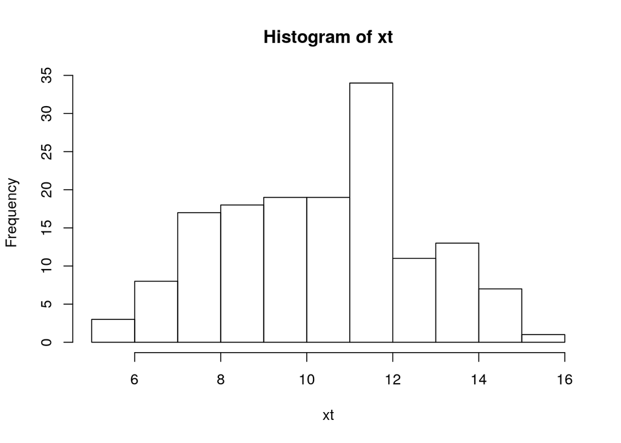

```r
hist(xt)
```

Mais uma vez, a aparência do histograma não é como esperada, devido ao problema amostral reportado anteriormente.

#### Criando sequência de tempo

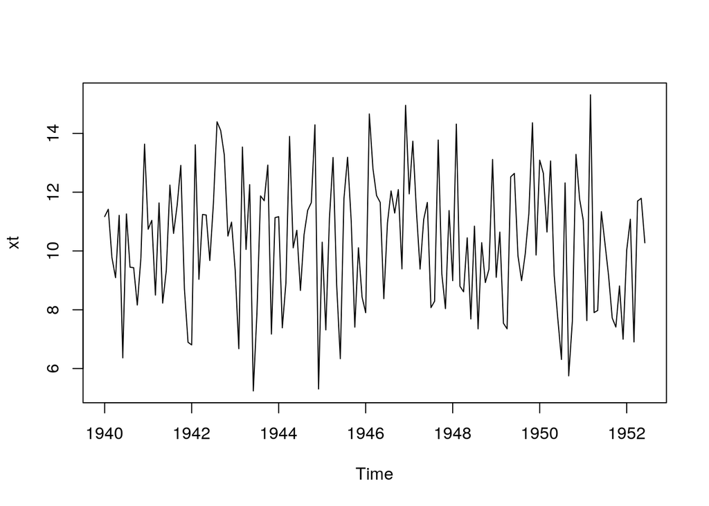

```r
xt <- ts(xt, start = c(1940, 1), frequency = 12)
plot.ts(xt)
```

#### Função de Autocorrelação (FAC)

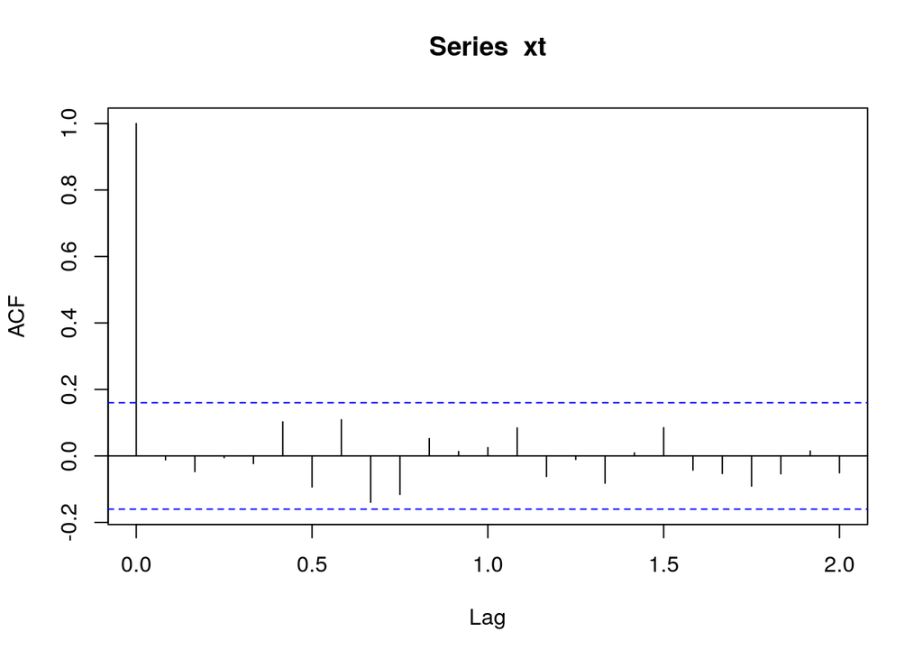

```r
acf(xt, 24)
```

#### Testes de hipótese

No gráfico acima, as linhas pontilhadas se referem ao intervalo de confiança a 95%. Nesse caso, estamos calculando um $H_0: \rho(1)=0$ e $H_1(1) \neq 0$ Podemos concluir que, estatisticamente, não existe correlação, já que não podemos rejeitar $H_0$ para quase todos os períodos no tempo.

#### Tendência linear

Imaginamos que a nossa série de tempo pode ser composta da seguinte forma:

$$y_t = a + bt + x_t$$
Supomos, também, $a=3$ e $b=0.15$, aplicados a uma sequencia de tempo que vai de 1 a 150. Aplicamos esses valores à nossa série de tempo inicial:

```r
yt <- 3+ 0.15*seq(150) + xt
```

Dessa forma, podemos visualizar a nova série, que possui tendência linear:

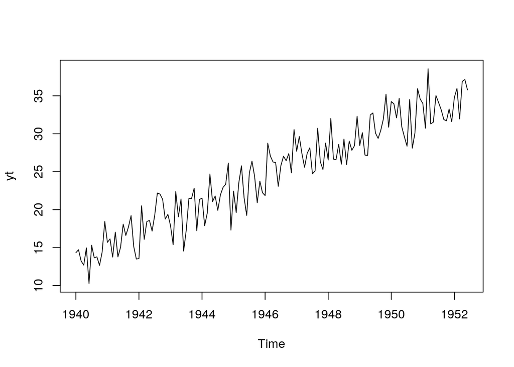

```r
plot.ts(yt)
```

Podemos, então, estimar um modelo de regressão linear simples. Com variável dependente $y_t$ e variável explicativa tempo:

```r
M <- lm(yt ~ seq(150))
summary(M)
```

```
##
## Call:
## lm(formula = yt ~ seq(150))
##
## Residuals:
##     Min      1Q  Median      3Q     Max
## -5.1924 -1.7033  0.1915  1.4444  5.1947
##
## Coefficients:
##              Estimate Std. Error t value Pr(>|t|)
## (Intercept) 13.573837   0.368428   36.84   <2e-16 ***
## seq(150)     0.146615   0.004233   34.63   <2e-16 ***
## ---
## Signif. codes:  0 '***' 0.001 '**' 0.01 '*' 0.05 '.' 0.1 ' ' 1
##
## Residual standard error: 2.245 on 148 degrees of freedom
## Multiple R-squared:  0.8902, Adjusted R-squared:  0.8894
## F-statistic:  1200 on 1 and 148 DF,  p-value: < 2.2e-16
```

Podemos notar que o intercepto é registrado como 13, e não como 3, conforme adicionamos no modelo. Isso ocorre porque temos média 10, e o intercepto passa a ser a soma entre esses dois valores.

Além disso, é possível verificar o comportamento do resíduo:

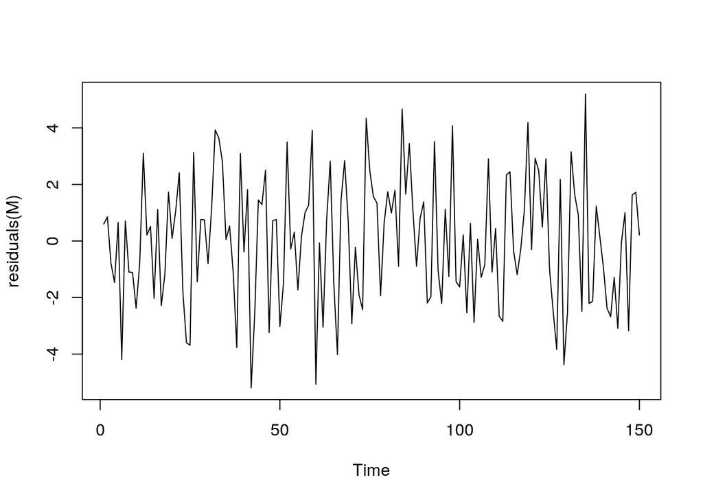

```r
plot.ts(residuals(M))
```

O gráfico dos resíduos é comparável ao nosso gráfico inicial. Por isso, esses gráficos são comparáveis caso façamos a subtração da média 10 do primeiro gráfico, e trazer a média para 10.